# Hands_on_I

Leire Asua Intxausti (leire.asua01@estudiant.upf.edu) & Núria Montalà Palau (nuria.montala01@estudiant.upf.edu)

Last update: 20 March, 2025

# 1 Load Necessary Libraries

```r
library(readr)
library(dplyr)
library(mice)
library(corrplot)
library(ggplot2)
library(gridExtra)
library(readxl)
library(openxlsx)
library(tidyr)
library(ggthemes)
library(cowplot)
library(grid)
library(gridExtra)
library(RColorBrewer)
library(stats)
library(ComplexHeatmap)
library(circlize)
```

# 2 Analysis of the Heart Disease Dataset

Load the data from [here](https://raw.githubusercontent.com/jpinero/DMI_2021/main/datasets/heart_disease_dataset.csv), and the description is [here](https://raw.githubusercontent.com/jpinero/DMI_2021/main/datasets/heart_disease_description.txt). The original dataset comes from [here](https://archive.ics.uci.edu/ml/datasets/Heart+Disease) and corresponds to the [processed cleveland data](https://archive.ics.uci.edu/ml/machine-learning-databases/heart-disease/processed.cleveland.data).

## 2.1 Perform an EDA on the dataset

```r
# See table separating item
lines <- readLines("data/heart_disease_dataset.csv", n = 10)
lines
```

```
##  [1] "age sex cp trestbps chol fbs restecg thalach exang oldpeak slope ca thal num patient_id"
##  [2] "63 1 1 145 233 1 2 150 0 2.3 3 0 6 0 1"
##  [3] "67 1 4 160 286 0 2 108 1 1.5 2 3 3 2 2"
##  [4] "67 1 4 120 229 0 2 129 1 2.6 2 2 7 1 3"
##  [5] "37 1 3 130 250 0 0 187 0 3.5 3 0 3 0 4"
##  [6] "41 0 2 130 204 0 2 172 0 1.4 1 0 3 0 5"
##  [7] "56 1 2 120 236 0 0 178 0 0.8 1 0 3 0 6"
##  [8] "62 0 4 140 268 0 2 160 0 3.6 3 2 3 3 7"
##  [9] "57 0 4 120 354 0 0 163 1 0.6 1 0 3 0 8"
## [10] "63 1 4 130 254 0 2 147 0 1.4 2 1 7 2 9"
```

```r
# Read the table
dataset <- read_table("data/heart_disease_dataset.csv")
View(dataset)

# Summary of the data
summarytools::dfSummary(dataset, stats = c("mean", "sd", "median", "iqr")) %>%
  print(method = "render")
```

Data Frame Summary

dataset

**Dimensions**: 303 x 15  
**Duplicates**: 0

| **No** | **Variable** | **Stats / Values** | **Freqs (% of Valid)** | **Graph** | **Valid** | **Missing** |
| --- | --- | --- | --- | --- | --- | --- |
| 1 | age [numeric] | Mean (sd) : 54.4 (9) min ≤ med ≤ max: 29 ≤ 56 ≤ 77 IQR (CV) : 13 (0.2) | 41 distinct values |  | 303 (100.0%) | 0 (0.0%) |
| 2 | sex [numeric] | Min : 0 Mean : 0.7 Max : 1 | 0 : 97 ( 32.0% ) 1 : 206 ( 68.0% ) |  | 303 (100.0%) | 0 (0.0%) |
| 3 | cp [numeric] | Mean (sd) : 3.2 (1) min ≤ med ≤ max: 1 ≤ 3 ≤ 4 IQR (CV) : 1 (0.3) | 1 : 23 ( 7.6% ) 2 : 50 ( 16.5% ) 3 : 86 ( 28.4% ) 4 : 144 ( 47.5% ) |  | 303 (100.0%) | 0 (0.0%) |
| 4 | trestbps [numeric] | Mean (sd) : 131.7 (17.6) min ≤ med ≤ max: 94 ≤ 130 ≤ 200 IQR (CV) : 20 (0.1) | 50 distinct values |  | 303 (100.0%) | 0 (0.0%) |
| 5 | chol [numeric] | Mean (sd) : 246.7 (51.8) min ≤ med ≤ max: 126 ≤ 241 ≤ 564 IQR (CV) : 64 (0.2) | 152 distinct values |  | 303 (100.0%) | 0 (0.0%) |
| 6 | fbs [numeric] | Min : 0 Mean : 0.1 Max : 1 | 0 : 258 ( 85.1% ) 1 : 45 ( 14.9% ) |  | 303 (100.0%) | 0 (0.0%) |
| 7 | restecg [numeric] | Mean (sd) : 1 (1) min ≤ med ≤ max: 0 ≤ 1 ≤ 2 IQR (CV) : 2 (1) | 0 : 151 ( 49.8% ) 1 : 4 ( 1.3% ) 2 : 148 ( 48.8% ) |  | 303 (100.0%) | 0 (0.0%) |
| 8 | thalach [numeric] | Mean (sd) : 149.6 (22.9) min ≤ med ≤ max: 71 ≤ 153 ≤ 202 IQR (CV) : 32.5 (0.2) | 91 distinct values |  | 303 (100.0%) | 0 (0.0%) |
| 9 | exang [numeric] | Min : 0 Mean : 0.3 Max : 1 | 0 : 204 ( 67.3% ) 1 : 99 ( 32.7% ) |  | 303 (100.0%) | 0 (0.0%) |
| 10 | oldpeak [numeric] | Mean (sd) : 1 (1.2) min ≤ med ≤ max: 0 ≤ 0.8 ≤ 6.2 IQR (CV) : 1.6 (1.1) | 40 distinct values |  | 303 (100.0%) | 0 (0.0%) |
| 11 | slope [numeric] | Mean (sd) : 1.6 (0.6) min ≤ med ≤ max: 1 ≤ 2 ≤ 3 IQR (CV) : 1 (0.4) | 1 : 142 ( 46.9% ) 2 : 140 ( 46.2% ) 3 : 21 ( 6.9% ) |  | 303 (100.0%) | 0 (0.0%) |
| 12 | ca [character] | 1. ? 2. 0 3. 1 4. 2 5. 3 | 4 ( 1.3% ) 176 ( 58.1% ) 65 ( 21.5% ) 38 ( 12.5% ) 20 ( 6.6% ) |  | 303 (100.0%) | 0 (0.0%) |
| 13 | thal [character] | 1. ? 2. 3 3. 6 4. 7 | 2 ( 0.7% ) 166 ( 54.8% ) 18 ( 5.9% ) 117 ( 38.6% ) |  | 303 (100.0%) | 0 (0.0%) |
| 14 | num [numeric] | Mean (sd) : 0.9 (1.2) min ≤ med ≤ max: 0 ≤ 0 ≤ 4 IQR (CV) : 2 (1.3) | 0 : 164 ( 54.1% ) 1 : 55 ( 18.2% ) 2 : 36 ( 11.9% ) 3 : 35 ( 11.6% ) 4 : 13 ( 4.3% ) |  | 303 (100.0%) | 0 (0.0%) |
| 15 | patient_id [numeric] | Mean (sd) : 152 (87.6) min ≤ med ≤ max: 1 ≤ 152 ≤ 303 IQR (CV) : 151 (0.6) | 303 distinct values |  | 303 (100.0%) | 0 (0.0%) |

Generated by summarytools 1.0.1 ([R](https://www.r-project.org/) version 4.4.2)  
2025-03-20

```r
# Variable analysis
colnames(dataset)
```

```
##  [1] "age"        "sex"        "cp"         "trestbps"   "chol"
##  [6] "fbs"        "restecg"    "thalach"    "exang"      "oldpeak"
## [11] "slope"      "ca"         "thal"       "num"        "patient_id"
```

```r
## NUMERICAL VAR

# age: age in years
# trestbps: resting blood pressure (in mm Hg on admission to the hospital)
# chol: serum cholestoral in mg/dl
# thalach: maximum heart rate achieved
# oldpeak: T depression induced by exercise relative to rest

## CATEGORICAL VAR

# sex: gender (1 = male; 0 = female)
# cp: chest pain type (1 = typical angina, 2 = atypical angina, 3 = non-anginal pain, 4 = asymptomatic)
# fbs: fasting blood sugar > 120 mg/dl (1 = true; 0 = false)
# restecg: resting electrocardiographic results (0 = normal, 1 = having ST-T wave abnormality, 2 = showing probable or definite left ventricular hypertrophy)
# exang: exercise induced angina (1 = yes; 0 = no)
# slope: the slope of the peak exercise ST segment (1 = upsloping, 2 = flat, 3 = downsloping)
# ca: number of major vessels (0-3) colored by flourosopy
# thal: 3 = normal; 6 = fixed defect; 7 = reversable defect
# num: diagnosis of heart disease (0 = < 50% diameter narrowing, 1 = > 50% diameter narrowing)

# Remove patient_id from the dataset, it was no used as attribute
heart_disease_dataset <- dataset %>%
  dplyr::select(-patient_id)

# Check for duplicates
heart_disease_dataset[duplicated(heart_disease_dataset), ] # no duplicates found
```

```
## # A tibble: 0 × 14
## # ℹ 14 variables: age <dbl>, sex <dbl>, cp <dbl>, trestbps <dbl>, chol <dbl>,
## #   fbs <dbl>, restecg <dbl>, thalach <dbl>, exang <dbl>, oldpeak <dbl>,
## #   slope <dbl>, ca <chr>, thal <chr>, num <dbl>
```

```r
# Check ca, thal, num
unique(heart_disease_dataset$ca) # "?" representing NA
```

```
## [1] "0" "3" "2" "1" "?"
```

```r
unique(heart_disease_dataset$thal) # "?" representing NA
```

```
## [1] "6" "3" "7" "?"
```

```r
unique(heart_disease_dataset$num) # also 2, 3, 4, convert into NA
```

```
## [1] 0 2 1 3 4
```

```r
# For categorical vars change numbers to labels, for numeric ones ensure they are numeric
heart_disease_dataset <- heart_disease_dataset %>%
  mutate(
    sex = factor(sex, levels = c(0, 1), labels = c("female", "male")),
    cp = factor(cp, levels = c(1,2,3,4), labels = c("typical", "atypical", "non-anginal", "asymptomatic")),
    fbs = factor(fbs, levels = c(0,1), labels = c("<120 mg/dl", ">120 mg/dl")),
    restecg = factor(restecg, levels = c(0,1,2), labels = c("normal", "abnormality", "hypertrophy")),
    exang = factor(exang, levels = c(0,1), labels = c("no", "yes")),
    slope = factor(slope, levels = c(1,2,3), labels = c("upsloping", "flat", "downsloping")),
    ca = factor(na_if(ca,"?"), levels = c(0,1,2,3)),
    thal = factor(na_if(thal,"?"), levels = c(3,6,7), labels = c("normal", "fixed", "reversable")),
    num = factor(num, levels = c(0,1), labels = c("< 50%", "> 50 %")),
    age = as.double(age),
    trestbps = as.double(trestbps),
    chol = as.double(chol),
    thalach = as.double(thalach),
    oldpeak = as.double(oldpeak)
  )
```

### 2.1.1 Imputation of missing values in categorical variables using mice

Inside mice package, polyreg method was used. This method applies polynomial regression to predict the missing values based on the relationship between the variable with missing values and the other variables in the dataset

```r
# Check for missing data (NA)
colSums(is.na(heart_disease_dataset))
```

```
##      age      sex       cp trestbps     chol      fbs  restecg  thalach
##        0        0        0        0        0        0        0        0
##    exang  oldpeak    slope       ca     thal      num
##        0        0        0        4        2       84
```

```r
# Impute missing data using mice
imput_data <- mice(heart_disease_dataset, method = "polyreg")
imput_data$predictorMatrix
```

```
##          age sex cp trestbps chol fbs restecg thalach exang oldpeak slope ca
## age        0   1  1        1    1   1       1       1     1       1     1  1
## sex        1   0  1        1    1   1       1       1     1       1     1  1
## cp         1   1  0        1    1   1       1       1     1       1     1  1
## trestbps   1   1  1        0    1   1       1       1     1       1     1  1
## chol       1   1  1        1    0   1       1       1     1       1     1  1
## fbs        1   1  1        1    1   0       1       1     1       1     1  1
## restecg    1   1  1        1    1   1       0       1     1       1     1  1
## thalach    1   1  1        1    1   1       1       0     1       1     1  1
## exang      1   1  1        1    1   1       1       1     0       1     1  1
## oldpeak    1   1  1        1    1   1       1       1     1       0     1  1
## slope      1   1  1        1    1   1       1       1     1       1     0  1
## ca         1   1  1        1    1   1       1       1     1       1     1  0
## thal       1   1  1        1    1   1       1       1     1       1     1  1
## num        1   1  1        1    1   1       1       1     1       1     1  1
##          thal num
## age         1   1
## sex         1   1
## cp          1   1
## trestbps    1   1
## chol        1   1
## fbs         1   1
## restecg     1   1
## thalach     1   1
## exang       1   1
## oldpeak     1   1
## slope       1   1
## ca          1   1
## thal        0   1
## num         1   0
```

```r
imp_heart_disease <- complete(imput_data)
View(imp_heart_disease)
```

### 2.1.2 Univariate EDA for Numerical Variables

Histograms: for showing the frequency of values in each numeric variable histograms were performed, while for checking the distribution of the data density lines were added. Combining both, the plots revealed outliers for chol, oldpeak and trestbps variables. Besides, plots represented poor normal distributions, that could be defined as skewed distributions, being oldpeak the least normal distributed.

```r
# Check again for numeric variables
numeric_cols <- sapply(imp_heart_disease, is.numeric)

# Summary of numeric variables
summary(imp_heart_disease[numeric_cols])
```

```
##       age           trestbps          chol          thalach         oldpeak
##  Min.   :29.00   Min.   : 94.0   Min.   :126.0   Min.   : 71.0   Min.   :0.00
##  1st Qu.:48.00   1st Qu.:120.0   1st Qu.:211.0   1st Qu.:133.5   1st Qu.:0.00
##  Median :56.00   Median :130.0   Median :241.0   Median :153.0   Median :0.80
##  Mean   :54.44   Mean   :131.7   Mean   :246.7   Mean   :149.6   Mean   :1.04
##  3rd Qu.:61.00   3rd Qu.:140.0   3rd Qu.:275.0   3rd Qu.:166.0   3rd Qu.:1.60
##  Max.   :77.00   Max.   :200.0   Max.   :564.0   Max.   :202.0   Max.   :6.20
```

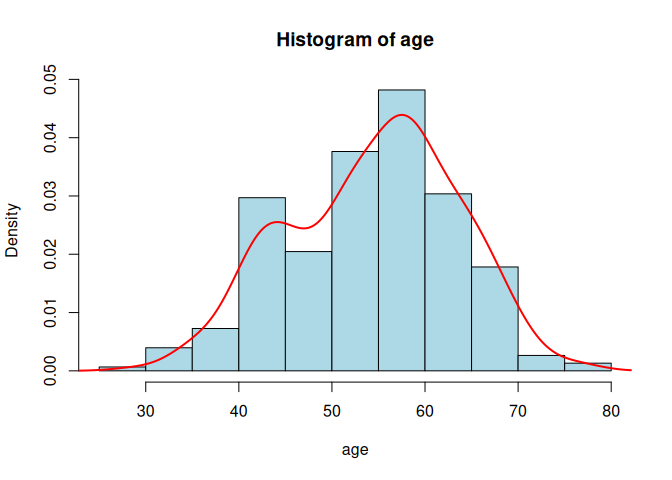

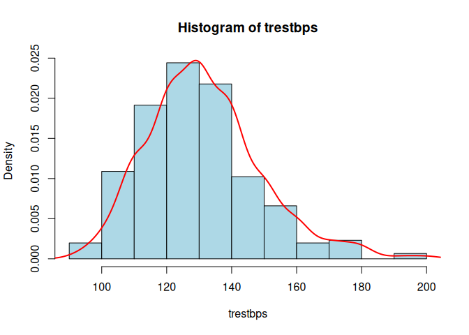

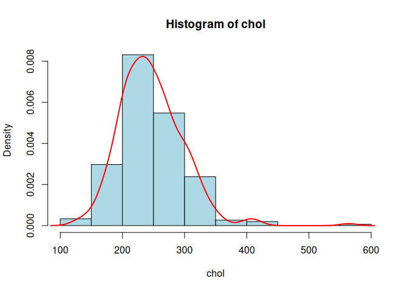

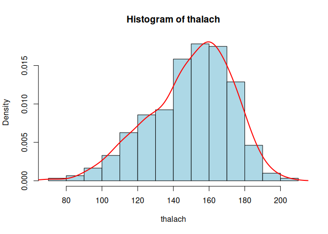

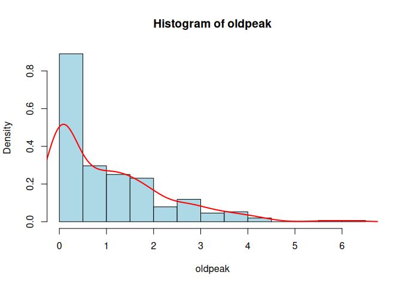

```r
# Histograms/density plots
for (col in names(imp_heart_disease)[numeric_cols]) {
  hist(
    imp_heart_disease[[col]],
    main = paste("Histogram of", col),
    xlab = col,
    col = "lightblue",
    freq = FALSE # for density plotting
  )
  lines(density(imp_heart_disease[[col]]), col = "red", lwd = 2) # lwd more widht to the line
}
```

Q-Q plots: after histograms, q-q plots were performed in order to check wether the variables were normal distributed or not. As mentioned before, the plots for most of the variables suggest that they do not fully follow a normal distribution, with some deviations from the reference line. For instance, oldpeak and trestbps exhibit heavy tails, showing notable deviations from the reference line. On the other hand, although the chol, thalach and age variables mostly follow the reference line, they show slight deviations at the tails which for some cases could be considered as outliers.

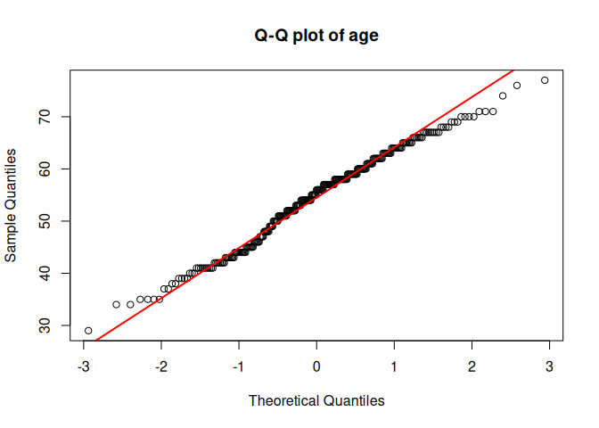

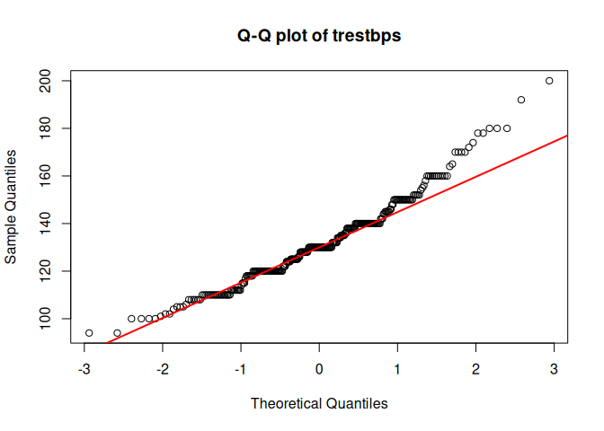

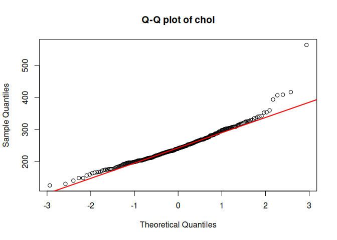

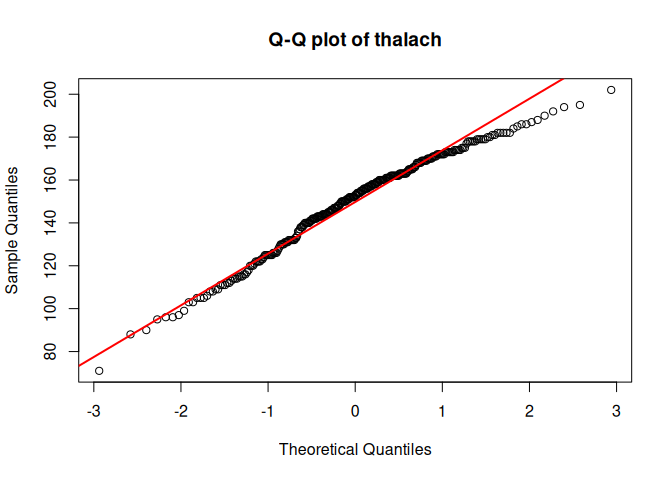

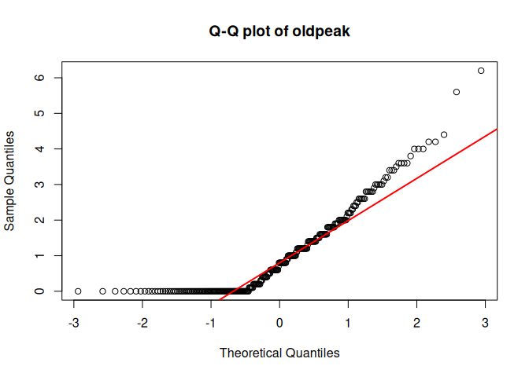

```r
for (col in names(imp_heart_disease)[numeric_cols]) {
  qqnorm(
    imp_heart_disease[[col]],
    main = paste("Q-Q plot of", col),
    xlab = "Theoretical Quantiles",
    ylab = "Sample Quantiles",
    col = "black",
  )
  qqline(imp_heart_disease[[col]], col = "red", lwd = 2)
}
```

Boxplots: finally, boxplots were created to assess distributions and to check for outliers. In chol and oldpeak variables some outliers were seen for further correction, while the outliers seen in talach and trestbps were defined as extreme but possible values. In age, 0 outliers were found.

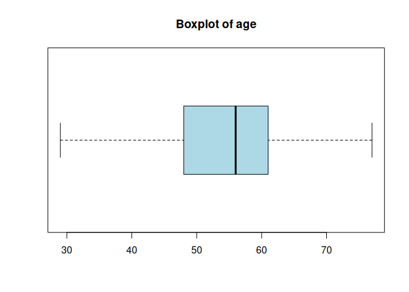

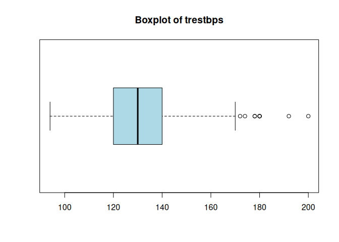

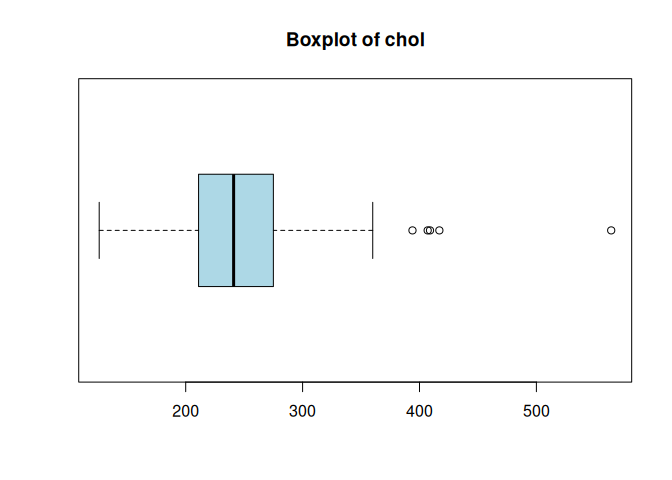

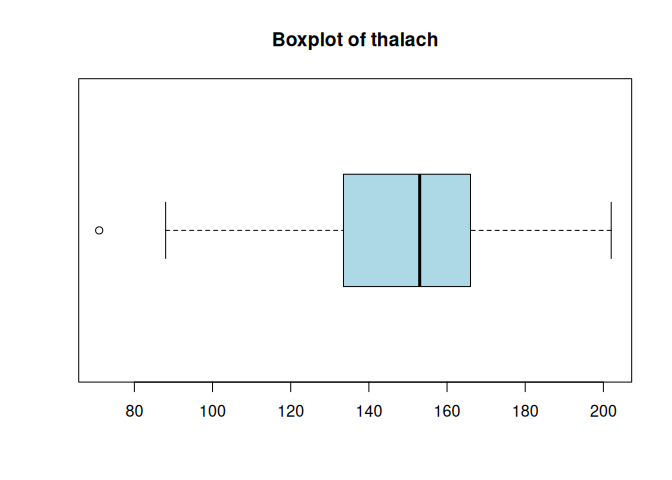

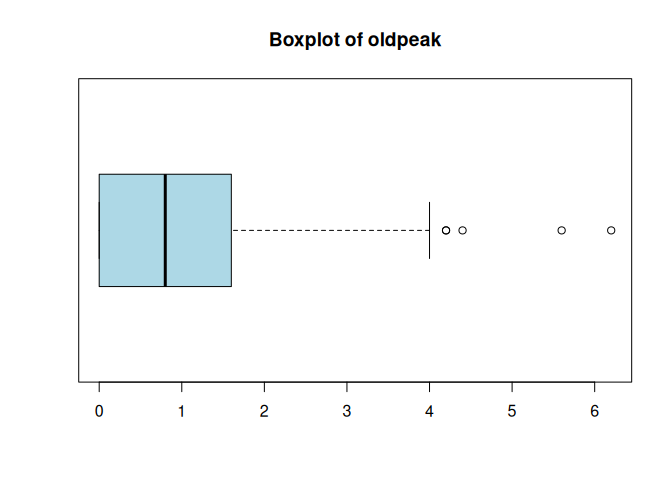

```r
# Boxplots of numeric variables
for (col in names(imp_heart_disease)[numeric_cols]) {
  boxplot(
    imp_heart_disease[[col]],
    main = paste("Boxplot of", col),
    horizontal = TRUE,
    col = "lightblue"
  )
}
```

Taking into account the outliers found in the boxplots, some of them were corrected.

- For trestbps, although some extreme values were identified as outliers, they were kept since they are not unreasonable for this variable.
- For chol, the most extreme value (564) was removed and the other outliers that were above the threshold (mean + 3 standard deviations) were replaced by the threshold value, ensuring not losing so much data.
- For talach, no significant outliers were found.
- For oldpeak, the outliers were imputed by replacing any values greater than the upper limit (Q3 + 1.5 * IQR) with the upper limit value, ensuring that these outliers do not affect the analysis.

Finally, boxplots were performed again in order to see the changes after managing the outliers.

```r
# trestbps: ouliers are extreme but possible, so keep them
out_trestbps <- boxplot.stats(imp_heart_disease$trestbps)$out
out_trestbps
```

```
## [1] 172 180 200 174 178 192 180 178 180
```

```r
# chol: remove the most extreme (564), replace the rest using mean/sd
out_chol <- boxplot.stats(imp_heart_disease$chol)$out
out_chol
```

```
## [1] 417 407 564 394 409
```

```r
imp_heart_disease <- imp_heart_disease[imp_heart_disease$chol !=564,]

mean_chol <- mean(imp_heart_disease$chol, na.rm = TRUE)
sd_chol <- sd(imp_heart_disease$chol, na.rm = TRUE)
upper_bound_3sd <- mean_chol + 3 * sd_chol

imp_heart_disease$chol[imp_heart_disease$chol > upper_bound_3sd] <- upper_bound_3sd

# talach: no important outliers
out_talach <- boxplot.stats(imp_heart_disease$talach)$out
out_talach
```

```r
# oldpeak: impute them
out_oldpeak <- boxplot.stats(imp_heart_disease$oldpeak)$out
out_oldpeak
```

```
## [1] 6.2 5.6 4.2 4.2 4.4
```

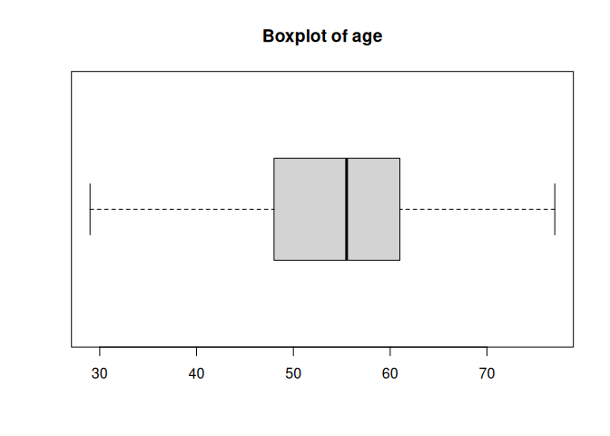

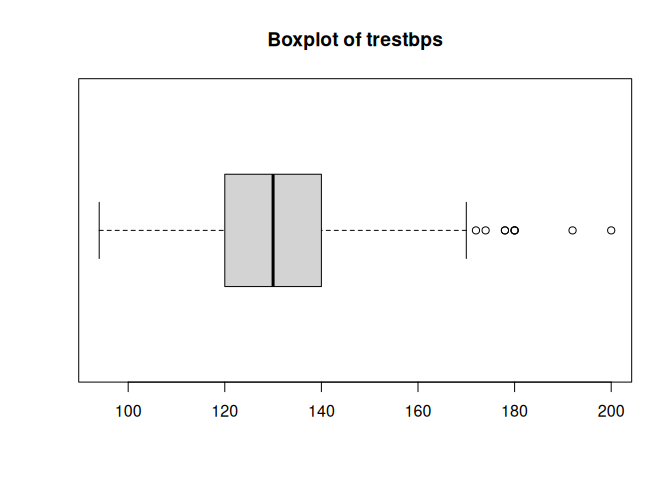

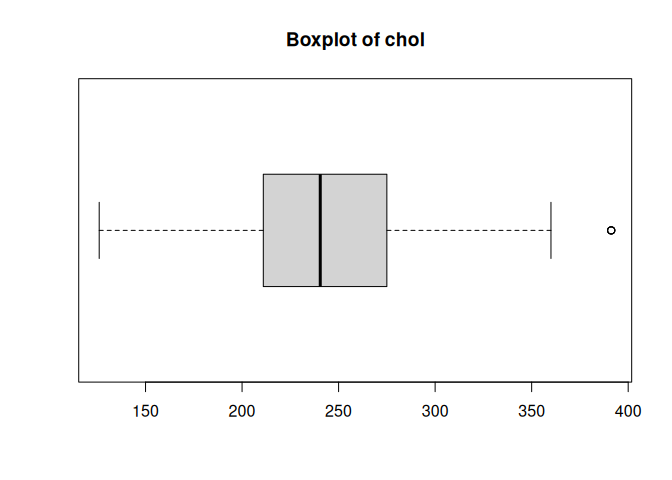

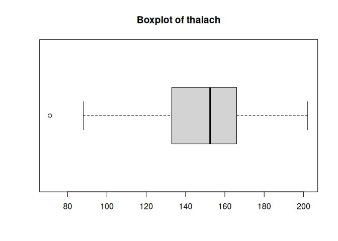

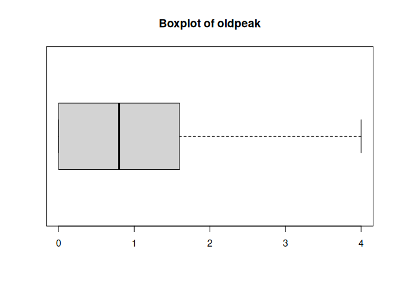

```r
q1_oldpeak <- quantile(imp_heart_disease$oldpeak, 0.25)
q3_oldpeak <- quantile(imp_heart_disease$oldpeak, 0.75)
iqr_oldpeak <- q3_oldpeak - q1_oldpeak
upper_iqr_oldpeak <- q3_oldpeak + 1.5 * iqr_oldpeak

imp_heart_disease$oldpeak[imp_heart_disease$oldpeak > upper_iqr_oldpeak] <- upper_iqr_oldpeak

# Boxplots of numeric variables after outliers managment
for (col in names(imp_heart_disease)[numeric_cols]) {
  boxplot(
    imp_heart_disease[[col]],
    main = paste("Boxplot of", col),
    horizontal = TRUE
  )
}
```

### 2.1.3 Univariate EDA for Categorical Variables

In order to visualize the distribution of categorical variables barplots were performed. As a result, it is found that some variables are less balanced than others, especially variables with 3 levels.

```r
# Check for categorical variables
categorical_cols <- sapply(imp_heart_disease, is.factor)

# Summary of categorical variables
summary(imp_heart_disease[categorical_cols])
```

```
##      sex                 cp              fbs             restecg    exang
##  female: 96   typical     : 23   <120 mg/dl:257   normal     :151   no :203
##  male  :206   atypical    : 50   >120 mg/dl: 45   abnormality:  4   yes: 99
##               non-anginal : 85                    hypertrophy:147
##               asymptomatic:144
##          slope     ca              thal         num
##  upsloping  :142   0:177   normal    :167   < 50% :181
##  flat       :139   1: 67   fixed     : 19   > 50 %:121
##  downsloping: 21   2: 38   reversable:116
##                    3: 20
```

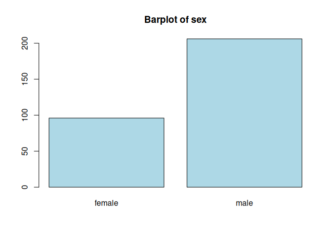

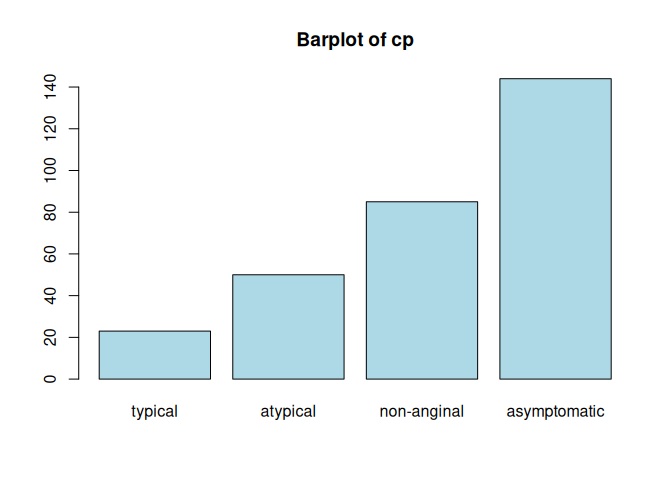

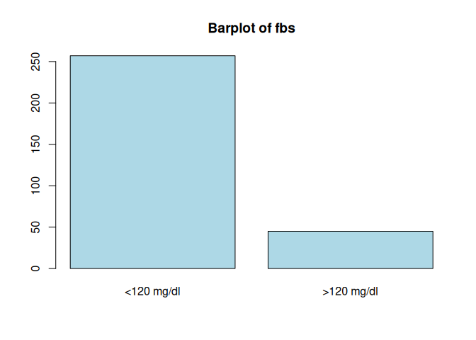

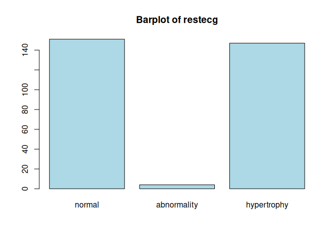

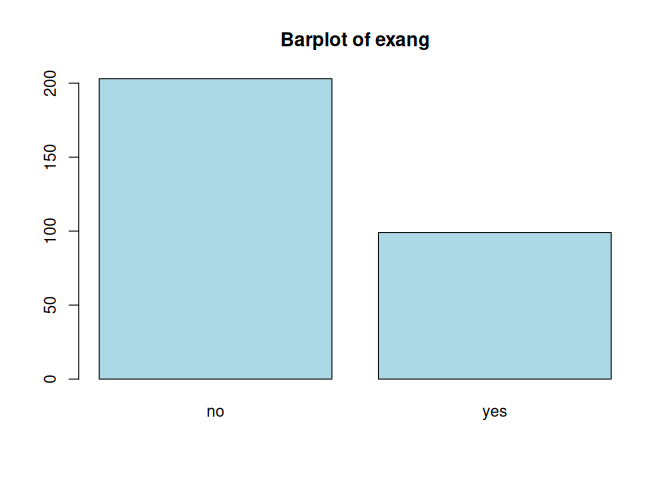

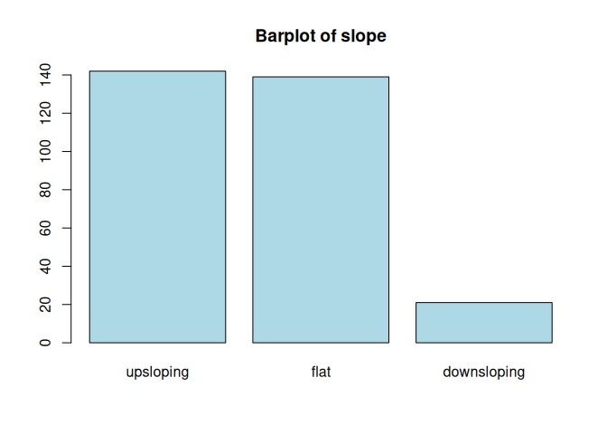

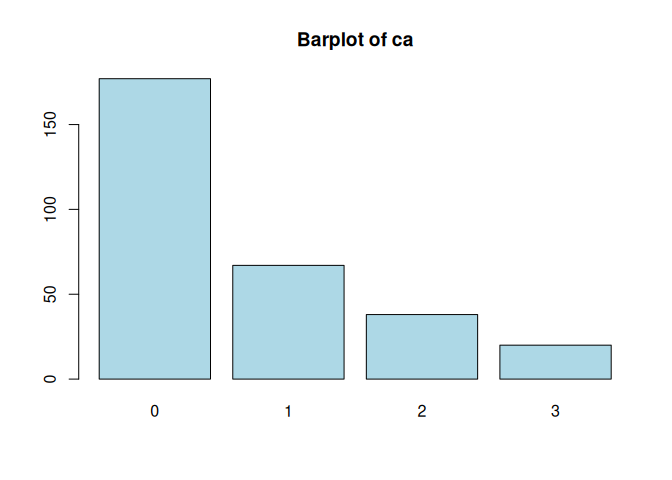

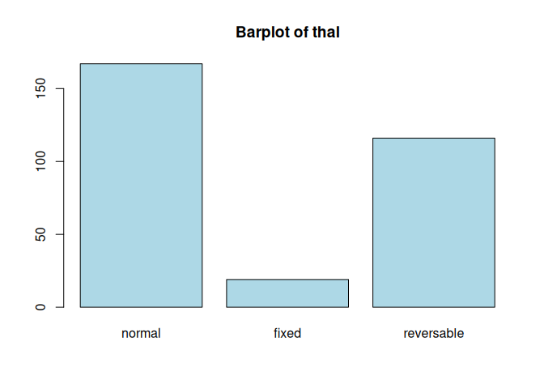

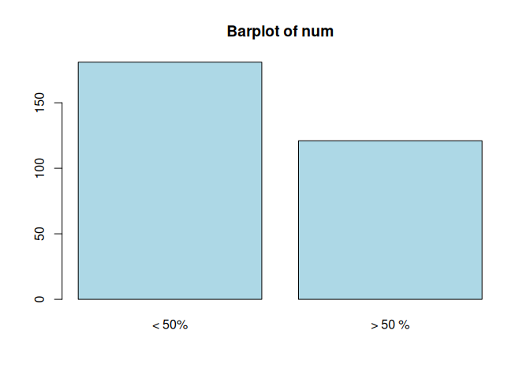

```r
# Barplots
for (col in names(imp_heart_disease)[categorical_cols]) {
  barplot(
    table(imp_heart_disease[[col]]),
    main = paste("Barplot of", col),
    col = "lightblue"
  )
}
```